# NYPD_Shooting_Data_History

Brandon Khuu

2024-03-02

#Import Libraries

Import the libraries needed to run the file

```r
library(readr)
library(dplyr)
```

```r
library(tidyr)
library(ggplot2)
library(caret)
library(randomForest)
```

#Import the file

Import the library in R studio. Add a header and do not convert the strings into a factor data type

```r
data1 <- read.csv("C:\\Users\\bkhuu\\ucb\\NYPD_Shooting_Incident_Data__Historic_.csv", header=TRUE, stringsAsFactors = FALSE)
```

## Data Summary

Initial data summary to describe the data from a surface level view.

```r
str(data1)
```

```
## 'data.frame':    27312 obs. of  21 variables:
##  $ INCIDENT_KEY           : int  228798151 137471050 147998800 146837977 58921844 219559682 85295722 71662474 83002139 86437261 ...
##  $ OCCUR_DATE             : chr  "05/27/2021" "06/27/2014" "11/21/2015" "10/09/2015" ...
##  $ OCCUR_TIME             : chr  "21:30:00" "17:40:00" "03:56:00" "18:30:00" ...
##  $ BORO                   : chr  "QUEENS" "BRONX" "QUEENS" "BRONX" ...
##  $ LOC_OF_OCCUR_DESC      : chr  "" "" "" "" ...
##  $ PRECINCT               : int  105 40 108 44 47 81 114 81 105 101 ...
##  $ JURISDICTION_CODE      : int  0 0 0 0 0 0 0 0 0 0 ...
##  $ LOC_CLASSFCTN_DESC     : chr  "" "" "" "" ...
##  $ LOCATION_DESC          : chr  "" "" "" "" ...
##  $ STATISTICAL_MURDER_FLAG: chr  "false" "false" "true" "false" ...
##  $ PERP_AGE_GROUP         : chr  "" "" "" "" ...
##  $ PERP_SEX               : chr  "" "" "" "" ...
##  $ PERP_RACE              : chr  "" "" "" "" ...
##  $ VIC_AGE_GROUP          : chr  "18-24" "18-24" "25-44" "<18" ...
##  $ VIC_SEX                : chr  "M" "M" "M" "M" ...
##  $ VIC_RACE               : chr  "BLACK" "BLACK" "WHITE" "WHITE HISPANIC" ...
##  $ X_COORD_CD             : num  1058925 1005028 1007668 1006537 1024922 ...
##  $ Y_COORD_CD             : num  180924 234516 209837 244511 262189 ...
##  $ Latitude               : num  40.7 40.8 40.7 40.8 40.9 ...
##  $ Longitude              : num  -73.7 -73.9 -73.9 -73.9 -73.9 ...
##  $ Lon_Lat                : chr  "POINT (-73.73083868899994 40.662964620000025)" "POINT (-73.92494232599995 40.81035186300006)" "POINT (-73.91549174199997 40.74260663300004)" "POINT (-73.91945661499994 40.83778200300003)" ...
```

```r
summary(data1)
```

```
##   INCIDENT_KEY        OCCUR_DATE         OCCUR_TIME            BORO
##  Min.   :  9953245   Length:27312       Length:27312       Length:27312
##  1st Qu.: 63860880   Class :character   Class :character   Class :character
##  Median : 90372218   Mode  :character   Mode  :character   Mode  :character
##  Mean   :120860536
##  3rd Qu.:188810230
##  Max.   :261190187
##
##  LOC_OF_OCCUR_DESC     PRECINCT      JURISDICTION_CODE LOC_CLASSFCTN_DESC
##  Length:27312       Min.   :  1.00   Min.   :0.0000    Length:27312
##  Class :character   1st Qu.: 44.00   1st Qu.:0.0000    Class :character
##  Mode  :character   Median : 68.00   Median :0.0000    Mode  :character
##                     Mean   : 65.64   Mean   :0.3269
##                     3rd Qu.: 81.00   3rd Qu.:0.0000
##                     Max.   :123.00   Max.   :2.0000
##                                      NA's   :2
##  LOCATION_DESC      STATISTICAL_MURDER_FLAG PERP_AGE_GROUP
##  Length:27312       Length:27312            Length:27312
##  Class :character   Class :character        Class :character
##  Mode  :character   Mode  :character        Mode  :character
##
##
##
##
##    PERP_SEX          PERP_RACE         VIC_AGE_GROUP        VIC_SEX
##  Length:27312       Length:27312       Length:27312       Length:27312
##  Class :character   Class :character   Class :character   Class :character
##  Mode  :character   Mode  :character   Mode  :character   Mode  :character
##
##
##
##
##    VIC_RACE           X_COORD_CD        Y_COORD_CD        Latitude
##  Length:27312       Min.   : 914928   Min.   :125757   Min.   :40.51
##  Class :character   1st Qu.:1000029   1st Qu.:182834   1st Qu.:40.67
##  Mode  :character   Median :1007731   Median :194487   Median :40.70
##                     Mean   :1009449   Mean   :208127   Mean   :40.74
##                     3rd Qu.:1016838   3rd Qu.:239518   3rd Qu.:40.82
##                     Max.   :1066815   Max.   :271128   Max.   :40.91
##                                                        NA's   :10
##    Longitude        Lon_Lat
##  Min.   :-74.25   Length:27312
##  1st Qu.:-73.94   Class :character
##  Median :-73.92   Mode  :character
##  Mean   :-73.91
##  3rd Qu.:-73.88
##  Max.   :-73.70
##  NA's   :10
```

## Check for missing values

See which (if any) columns have missing values and if there are any things we need to impute for analysis and models going forward.

Depending on the columns and values we can decide on the imputation method.

```r
colSums(is.na(data1))
```

```
##            INCIDENT_KEY              OCCUR_DATE              OCCUR_TIME
##                       0                       0                       0
##                    BORO       LOC_OF_OCCUR_DESC                PRECINCT
##                       0                       0                       0
##       JURISDICTION_CODE      LOC_CLASSFCTN_DESC           LOCATION_DESC
##                       2                       0                       0
## STATISTICAL_MURDER_FLAG          PERP_AGE_GROUP                PERP_SEX
##                       0                       0                       0
##               PERP_RACE           VIC_AGE_GROUP                 VIC_SEX
##                       0                       0                       0
##                VIC_RACE              X_COORD_CD              Y_COORD_CD
##                       0                       0                       0
##                Latitude               Longitude                 Lon_Lat
##                      10                      10                       0
```

## Convert dates to Date format

Convert the date format into something a little easier to work with

```r
data1$OCCUR_DATE <- as.Date(data1$OCCUR_DATE, "%m/%d/%Y")
```

##Exploratory analysis

Do some basic analysis and visualization via graphs

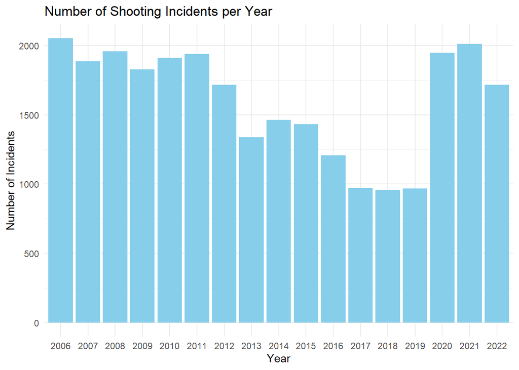

```r
data1 %>%
  mutate(Year = format(OCCUR_DATE, "%Y")) %>%
  group_by(Year) %>%
  summarise(Incidents = n()) %>%
  ggplot(aes(x = Year, y = Incidents)) +
  geom_bar(stat = "identity", fill = "skyblue") +
  labs(title = "Number of Shooting Incidents per Year",
       x = "Year",
       y = "Number of Incidents") +
  theme_minimal()
```

The graph above shows the number of shootings per years

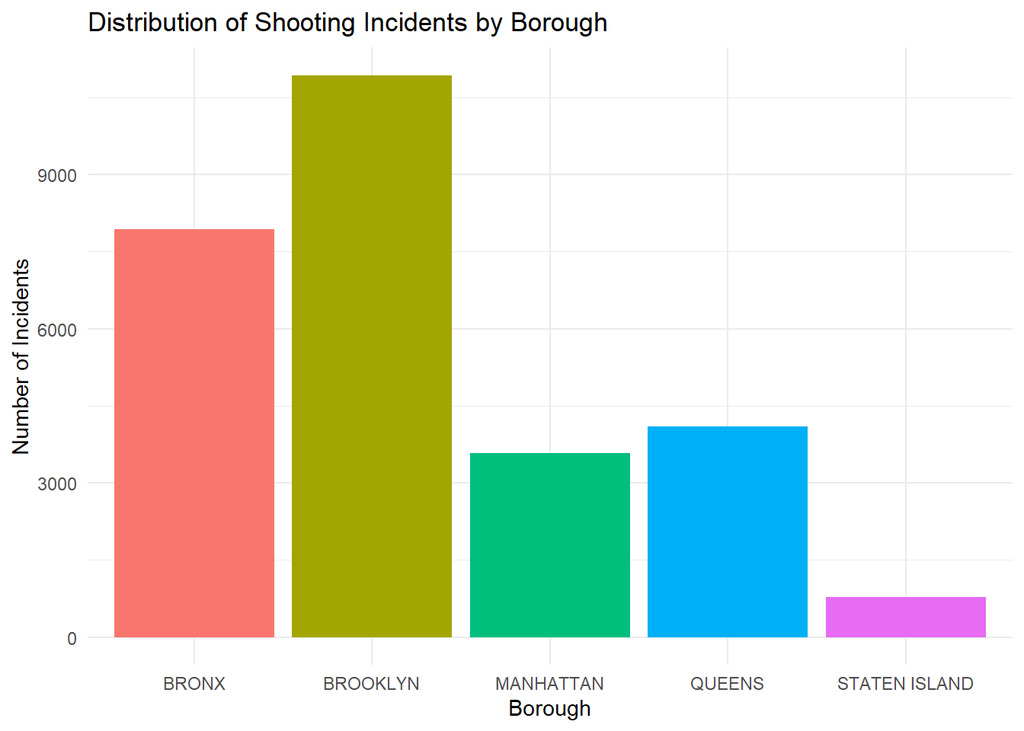

```r
data1 %>%
  group_by(BORO) %>%
  summarise(Incidents = n()) %>%
  ggplot(aes(x = BORO, y = Incidents, fill = BORO)) +
  geom_bar(stat = "identity") +
  labs(title = "Distribution of Shooting Incidents by Borough",
       x = "Borough",
       y = "Number of Incidents") +
  theme_minimal() +
  theme(legend.position = "none")
```

This graph shows the number of shootings per boro.

#Preparing data for the model

##set historical dates creating a filter for older dates to be used in the future

```r
# Filter data to include only incidents before the specified date
data_before_date <- filter(data1, OCCUR_DATE < as.Date("2024-03-05"))

# Create a new column for the day of the year using as.numeric and format instead of yday
data_before_date$DayOfYear <- as.numeric(format(data_before_date$OCCUR_DATE, "%j"))
```

Splitting data into training sets and testing sets. Setting seed to “123” which will allow for reproducibility.

```r
# Splitting the data into training and testing sets
set.seed(123)
training_indices <- createDataPartition(data_before_date$DayOfYear, p=0.8, list=FALSE)
training_data <- data_before_date[training_indices,]
testing_data <- data_before_date[-training_indices,]
```

Train the model

```r
model <- randomForest(DayOfYear ~ ., data=training_data[,-which(names(training_data) %in% c("OCCUR_DATE"))], ntree=100, na.action = na.omit)
```

Test the model

```r
# Calculating the Mean Squared Error (MSE) for the model's predictions, ensuring no NA values are included in the calculation
actual_days <- testing_data$DayOfYear
predicted_days <- predict(model, newdata=testing_data[,-which(names(testing_data) %in% c("OCCUR_DATE", "DayOfYear"))])

# Filtering out any NA values from actual_days and predicted_days before calculating MSE
valid_indices <- !is.na(actual_days) & !is.na(predicted_days)
mse <- mean((actual_days[valid_indices] - predicted_days[valid_indices])^2, na.rm = TRUE)
print(paste("Mean Squared Error (MSE):", mse))
```

```
## [1] "Mean Squared Error (MSE): 5761.17499135467"
```

Accuracy of the model was scored using Mean Squared Error. MSE: 5761.17499135467

```r
# Ensuring the prediction is a numeric value and handling potential NA values
current_year_incident_prediction <- na.omit(predict(model, newdata=testing_data[,-which(names(testing_data) %in% c("OCCUR_DATE", "DayOfYear"))]))
if(length(current_year_incident_prediction) > 0) {
  # Extracting the current year from the system's date
  current_year <- format(Sys.Date(), "%Y")
  # Converting the mean of predictions to a future date
  predicted_future_date <- as.Date(paste(current_year, "-01-01", sep="")) + mean(current_year_incident_prediction) - 1
  print(paste("Predicted future date of the next incident:", as.character(predicted_future_date)))
} else {
  print("Unable to predict future date due to insufficient data or model prediction error.")
}
```

```
## [1] "Predicted future date of the next incident: 2024-07-06"
```

Predicted future date of the next incident using the testing data: 2024-07-06